# Read Homer Output Analysis - For Ref/Alt

Can you pull out a couple examples of TFs (maybe 1 or 2) from these 73K and identify which part of the motif is affected by the SNP? I bet it will be the part of a motif where there is a very heavy weight on one particular nucleotide and messing that up results in failure to identify the motif with the alternative allele.

also, could you show one or two examples of TFs from the 69K set, where searching the reference genome fails to identify a motif but searching with the alternative allele finds it?

Similarly, I bet the SNPs occur in the super important core part of the motif with high probabilities (from the PWM) for that nucleotide. Do you have experience making sequence logos? they’re fun plots to show the important of each nucleotide in a motif?

Limitations: only looks at positive strand

```r
# source("https://bioconductor.org/biocLite.R")
# BiocManager::install("seqLogo")
library(seqLogo) # makePWM
library(stringr) # read.fasta, write.fasta
library(data.table)
library(dplyr)
library(glue)
library(matrixStats)
library(ggthemes)
```

```r
in_ref_not_alt_SNP <- fread("/Users/kathryntsai/OneDrive\ -\ Villanova\ University/College/2018-2019/Summer\ 2019/TFs_eQTLs_Research/RProjects/Project2/q2_3_output/in_ref_not_alt_SNP.txt") # 264905 x 8
```

```
|--------------------------------------------------|
|==================================================|
```

```r
in_alt_not_ref_SNP <- fread("/Users/kathryntsai/OneDrive\ -\ Villanova\ University/College/2018-2019/Summer\ 2019/TFs_eQTLs_Research/RProjects/Project2/q2_3_output/in_alt_not_ref_SNP.txt") # 269853 x 8
a_gene_snp <- fread("/Users/kathryntsai/OneDrive\ -\ Villanova\ University/College/2018-2019/Summer\ 2019/TFs_eQTLs_Research/RProjects/Project2/q2_3_output/a_gene_snp.txt") # 925540 x 14
```

```
|--------------------------------------------------|
|==================================================|
```

```r
a_gene_snp$SNPWindow <- paste("chromosome:GRCh37:",a_gene_snp$SNPChr, ":", a_gene_snp$SNPWindowStart, ":", a_gene_snp$SNPWindowEnd,":1", sep="") # 925540 x 15
```

Using only motifs on positive strands, sort motifs by Motif Score Change # data points with value of n in z_test_group

```r
x1_s <- x1 %>% sample_n(10000)
x2_s <- x2 %>% sample_n(10000)
fwrite(x1_s, "/Users/kathryntsai/OneDrive - Villanova University/College/2018-2019/Summer 2019/TFs_eQTLs_Research/RProjects/Project2/q2_3_output/x1_s_ref.txt", sep="\t")
fwrite(x2_s, "/Users/kathryntsai/OneDrive - Villanova University/College/2018-2019/Summer 2019/TFs_eQTLs_Research/RProjects/Project2/q2_3_output/x2_s_alt.txt", sep="\t")
# x1_s <- fread("/Users/kathryntsai/OneDrive - Villanova University/College/2018-2019/Summer 2019/TFs_eQTLs_Research/RProjects/Project2/q2_3_output/x1_s_ref.txt", sep='\t')
# x2_s <- fread("/Users/kathryntsai/OneDrive - Villanova University/College/2018-2019/Summer 2019/TFs_eQTLs_Research/RProjects/Project2/q2_3_output/x2_s_alt.txt", sep='\t')
z <- x1_s[x1_s$"ref_Strand" == "+",]
ref_test_group <- z[order(z$"ref_MotifScore", decreasing=T),]
z <- x2_s[x2_s$"alt_Strand" == "+",]
alt_test_group <- z[order(z$"alt_MotifScore", decreasing=T),]
```

Todo: detect # motifs without hardcoding it in

```r
# used forklift to rename all the motifs
motifs_table <- data.frame(read.table("/Users/kathryntsai/OneDrive\ -\ Villanova\ University/College/2018-2019/Summer\ 2019/TFs_eQTLs_Research/RProjects/Project2/q2_3_investigation/motifs/motif1.motif", sep="\t", header=F,nrow=1)[,2])
colnames(motifs_table) <- "Motif Name"
n = 429
for (i in 2:n){
  z <- read.table(paste("/Users/kathryntsai/OneDrive\ -\ Villanova\ University/College/2018-2019/Summer\ 2019/TFs_eQTLs_Research/RProjects/Project2/q2_3_investigation/motifs/motif", i, ".motif", sep=""), sep="\t", header=F,nrow=1)[,2]
  z <- data.frame(z)
  colnames(z) <- "Motif Name"
  motifs_table <- rbind(motifs_table, z)
}
motifs_table <- cbind(motifs_table, 1:n)
colnames(motifs_table)[2] <- "Num"
# 429 x 2
```

```r
ref_test_group_file <- left_join(ref_test_group, motifs_table) # 10051 x 9
```

```
Column `Motif Name` joining character vector and factor, coercing into character vector
```

```r
ref_test_group_file$SNPPosInFasta <- 0.001
ref_test_group_with_fasta <- left_join(ref_test_group_file, a_gene_snp[!duplicated(a_gene_snp$fasta_seq_og),]) # also by 'SNP'
ref_test_group_with_fasta$ref_Offset <- ref_test_group_with_fasta$ref_Offset + 21
ref_test_group_with_fasta <- ref_test_group_with_fasta[which(str_sub(ref_test_group_with_fasta$fasta_seq_og, 21, 21) == ref_test_group_with_fasta$OtherAllele), ] # only necessary if you didn't use old a_gene_snp file for homer input
counter_of_excluded_data <- 0
```

```r
i=1
## make_PWM_and_get_motif_sequence_for_1_motif
impt_table <- read.table(paste("/Users/kathryntsai/OneDrive\ -\ Villanova\ University/College/2018-2019/Summer\ 2019/TFs_eQTLs_Research/RProjects/Project2/q2_3_investigation/motifs/motif", ref_test_group_with_fasta[i,"Num"], ".motif", sep=""), sep="\t", skip=1, header=F, stringsAsFactors=FALSE)
colnames(impt_table) <- c("A", "C", "G", "T")
max_TF_motifs <- data.frame(cbind(data.frame(rowMaxs(as.matrix(impt_table), cols=T)), 1:nrow(impt_table), colnames(impt_table)[apply(impt_table,1,which.max)]))
colnames(max_TF_motifs) <- c("Num", "Index", "Base")
tf_motif <- paste(max_TF_motifs$Base, collapse="", sep="")
if (ref_test_group_with_fasta$ref_Offset[i] >= (21 - nchar(tf_motif)) & ref_test_group_with_fasta$ref_Offset[i] < 21)
{
    ref_test_group_with_fasta$SNPPosInFasta[i] <- 21 - ref_test_group_with_fasta$ref_Offset[i]+1
    allele_pwms <- data.table(impt_table[ref_test_group_with_fasta$SNPPosInFasta[i], ref_test_group_with_fasta$AssessedAllele[i]],
                              impt_table[ref_test_group_with_fasta$SNPPosInFasta[i], ref_test_group_with_fasta$OtherAllele[i]])
    colnames(allele_pwms) <- c("AssessedPWM", "OtherPWM")
    all_snp_pwms_ref <- max_TF_motifs[21 - ref_test_group_with_fasta$ref_Offset[i], ] # make this rbind later
    all_snp_pwms_ref <- cbind(all_snp_pwms_ref, i, ref_test_group_with_fasta[i,], allele_pwms) # make this cbind later
} else {
  all_snp_pwms_ref <- data.table(NA, NA, NA, i, ref_test_group_with_fasta[i]) # to begin
  colnames(all_snp_pwms_ref) <- c("Num", "Index", "Base", "i", colnames(ref_test_group_with_fasta))
  counter_of_excluded_data <- counter_of_excluded_data + 1
}

for (i in 2:nrow(ref_test_group_with_fasta)){
  impt_table <- read.table(paste("/Users/kathryntsai/OneDrive\ -\ Villanova\ University/College/2018-2019/Summer\ 2019/TFs_eQTLs_Research/RProjects/Project2/q2_3_investigation/motifs/motif", ref_test_group_with_fasta[i,"Num"], ".motif", sep=""), sep="\t", skip=1, header=F, stringsAsFactors=FALSE)
  colnames(impt_table) <- c("A", "C", "G", "T")
  max_TF_motifs <- data.frame(cbind(data.frame(rowMaxs(as.matrix(impt_table), cols=T)), 1:nrow(impt_table), colnames(impt_table)[apply(impt_table,1,which.max)]))
  colnames(max_TF_motifs) <- c("Num", "Index", "Base")
  tf_motif <- paste(max_TF_motifs$Base, collapse="", sep="")  # CATGCATATGCATAT

  ## does_TF_hit_SNP_if_so_get_position
  if (ref_test_group_with_fasta$ref_Offset[i] >= (21 - nchar(tf_motif)) & ref_test_group_with_fasta$ref_Offset[i] < 21) # if offset = 21, skip this
  {
      ref_test_group_with_fasta$SNPPosInFasta[i] <- 21 - ref_test_group_with_fasta$ref_Offset[i]
      allele_pwms <- data.table(impt_table[ref_test_group_with_fasta$SNPPosInFasta[i], ref_test_group_with_fasta$AssessedAllele[i]],
                              impt_table[ref_test_group_with_fasta$SNPPosInFasta[i], ref_test_group_with_fasta$OtherAllele[i]])
      colnames(allele_pwms) <- c("AssessedPWM", "OtherPWM")
      row_to_bind <- data.frame(max_TF_motifs[21 - ref_test_group_with_fasta$ref_Offset[i], ], i, ref_test_group_with_fasta[i,], allele_pwms)
      colnames(row_to_bind) <- colnames(all_snp_pwms_ref)
      all_snp_pwms_ref <- rbind(all_snp_pwms_ref, row_to_bind)
  } else {
    counter_of_excluded_data <- counter_of_excluded_data + 1
  }
}
all_snp_pwms_ref <- all_snp_pwms_ref[!is.na(all_snp_pwms_ref$Num),]
```

```r
colnames(all_snp_pwms_ref) <- c("Num", "Index", "Base", "i", "SNPWindow", "SNP", "SNPWindow2", "Offset", "Sequence", "Motif Name", "Strand", "MotifScore", "Num1", "SNPPosInFasta", "Gene", "GeneSymbol", "GeneChr", "GenePos", "SNPChr", "SNPPos", "AssessedAllele", "OtherAllele", "SNPWindowStart", "SNPWindowEnd", "fasta_seq_og", "fasta_seq_mod", "AssessedPWM", "OtherPWM")
```

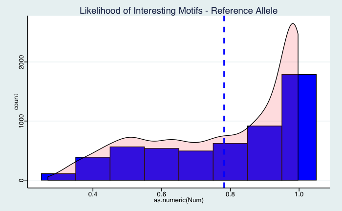

```r
ggplot(all_snp_pwms_ref, aes(x=as.numeric(Num))) +
  geom_histogram(binwidth=.1, color="black", fill="blue") +
  theme_stata() +
  geom_density(alpha=.2, fill="#FF6666", aes(y=..count../8)) +
  geom_vline(aes(xintercept=mean(as.numeric(Num))),
            color="blue", linetype="dashed", size=1) +
  ggtitle("Likelihood of Interesting Motifs - Reference Allele")
```

For alt

```r
alt_test_group_file <- left_join(alt_test_group, motifs_table) # 9901 x 9
```

```
Column `Motif Name` joining character vector and factor, coercing into character vector
```

```r
alt_test_group_file$SNPPosInFasta <- 0.001
alt_test_group_with_fasta <- left_join(alt_test_group_file, a_gene_snp[!duplicated(a_gene_snp$fasta_seq_og),]) # also by 'SNP'
alt_test_group_with_fasta$alt_Offset <- alt_test_group_with_fasta$alt_Offset + 21
alt_test_group_with_fasta <- alt_test_group_with_fasta[which(str_sub(alt_test_group_with_fasta$fasta_seq_og, 21, 21) == alt_test_group_with_fasta$OtherAllele), ] # 37x20, only necessary if you didn't use old a_gene_snp file for homer input
counter_of_excluded_data <- 0
```

```r
i=1
## make_PWM_and_get_motif_sequence_for_1_motif
impt_table <- read.table(paste("/Users/kathryntsai/OneDrive\ -\ Villanova\ University/College/2018-2019/Summer\ 2019/TFs_eQTLs_Research/RProjects/Project2/q2_3_investigation/motifs/motif", alt_test_group_with_fasta[i,"Num"], ".motif", sep=""), sep="\t", skip=1, header=F, stringsAsFactors=FALSE)
colnames(impt_table) <- c("A", "C", "G", "T")
max_TF_motifs <- data.frame(cbind(data.frame(rowMaxs(as.matrix(impt_table), cols=T)), 1:nrow(impt_table), colnames(impt_table)[apply(impt_table,1,which.max)]))
colnames(max_TF_motifs) <- c("Num", "Index", "Base")
tf_motif <- paste(max_TF_motifs$Base, collapse="", sep="")
## get_fasta_seq_and_get_rid_of_matches_that_do_not_work: Where does the SNP hit the TF? for alt_test_group: I think eQTLGen is zero-indexed.
## does_TF_hit_SNP_if_so_get_position
if (alt_test_group_with_fasta$alt_Offset[i] >= (21 - nchar(tf_motif)) & alt_test_group_with_fasta$alt_Offset[i] < 21)
{
    alt_test_group_with_fasta$SNPPosInFasta[i] <- 21 - alt_test_group_with_fasta$alt_Offset[i]+1
    allele_pwms <- data.table(impt_table[alt_test_group_with_fasta$SNPPosInFasta[i], alt_test_group_with_fasta$AssessedAllele[i]],
                              impt_table[alt_test_group_with_fasta$SNPPosInFasta[i], alt_test_group_with_fasta$OtherAllele[i]])
    colnames(allele_pwms) <- c("AssessedPWM", "OtherPWM")
    all_snp_pwms_alt <- max_TF_motifs[21 - alt_test_group_with_fasta$alt_Offset[i], ] # make this rbind later
    all_snp_pwms_alt <- cbind(all_snp_pwms_alt, i, alt_test_group_with_fasta[i,], allele_pwms) # make this cbind later
} else {
  all_snp_pwms_alt <- data.table(NA, NA, NA, i, alt_test_group_with_fasta[i,], allele_pwms) # to begin
  colnames(all_snp_pwms_alt) <- c("Num", "Index", "Base", "i", colnames(alt_test_group_with_fasta), colnames(allele_pwms))
  counter_of_excluded_data <- counter_of_excluded_data + 1
}

for (i in 2:nrow(alt_test_group_with_fasta)){
  impt_table <- read.table(paste("/Users/kathryntsai/OneDrive\ -\ Villanova\ University/College/2018-2019/Summer\ 2019/TFs_eQTLs_Research/RProjects/Project2/q2_3_investigation/motifs/motif", alt_test_group_with_fasta[i,"Num"], ".motif", sep=""), sep="\t", skip=1, header=F, stringsAsFactors=FALSE)
  colnames(impt_table) <- c("A", "C", "G", "T")
  max_TF_motifs <- data.frame(cbind(data.frame(rowMaxs(as.matrix(impt_table), cols=T)), 1:nrow(impt_table), colnames(impt_table)[apply(impt_table,1,which.max)]))
  colnames(max_TF_motifs) <- c("Num", "Index", "Base")
  tf_motif <- paste(max_TF_motifs$Base, collapse="", sep="")  # CATGCATATGCATAT

  ## does_TF_hit_SNP_if_so_get_position
  if (alt_test_group_with_fasta$alt_Offset[i] >= (21 - nchar(tf_motif)) & alt_test_group_with_fasta$alt_Offset[i] < 21) # if offset = 21, skip this
  {
      alt_test_group_with_fasta$SNPPosInFasta[i] <- 21 - alt_test_group_with_fasta$alt_Offset[i]
      allele_pwms <- data.table(impt_table[alt_test_group_with_fasta$SNPPosInFasta[i], alt_test_group_with_fasta$AssessedAllele[i]],
                              impt_table[alt_test_group_with_fasta$SNPPosInFasta[i], alt_test_group_with_fasta$OtherAllele[i]])
      colnames(allele_pwms) <- c("AssessedPWM", "OtherPWM")
      row_to_bind <- data.frame(max_TF_motifs[21 - alt_test_group_with_fasta$alt_Offset[i], ], i, alt_test_group_with_fasta[i,], allele_pwms)
      colnames(row_to_bind) <- colnames(all_snp_pwms_alt)
      all_snp_pwms_alt <- rbind(all_snp_pwms_alt, row_to_bind)
  } else {
    counter_of_excluded_data <- counter_of_excluded_data + 1
  }
}
all_snp_pwms_alt <- all_snp_pwms_alt[!is.na(all_snp_pwms_alt$Num),]
```

```r
# changed SNP placement
colnames(all_snp_pwms_alt) <- c("Num", "Index", "Base", "i", "SNPWindow", "SNP", "SNPWindow2", "Offset", "Sequence", "Motif Name", "Strand", "MotifScore", "Num1", "SNPPosInFasta", "Gene", "GeneSymbol", "GeneChr", "GenePos", "SNPChr", "SNPPos", "AssessedAllele", "OtherAllele", "SNPWindowStart", "SNPWindowEnd", "fasta_seq_og", "fasta_seq_mod", "AssessedPWM", "OtherPWM")
```

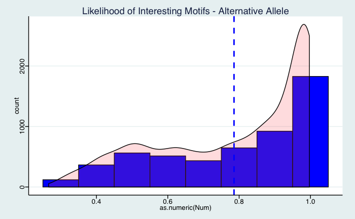

```r
ggplot(all_snp_pwms_alt, aes(x=as.numeric(Num))) +
  geom_histogram(binwidth=.1, color="black", fill="blue") +
  theme_stata() +
  geom_density(alpha=.2, fill="#FF6666", aes(y=..count../8)) +
  geom_vline(aes(xintercept=mean(as.numeric(Num))),
            color="blue", linetype="dashed", size=1) +
  ggtitle("Likelihood of Interesting Motifs - Alternative Allele")
```

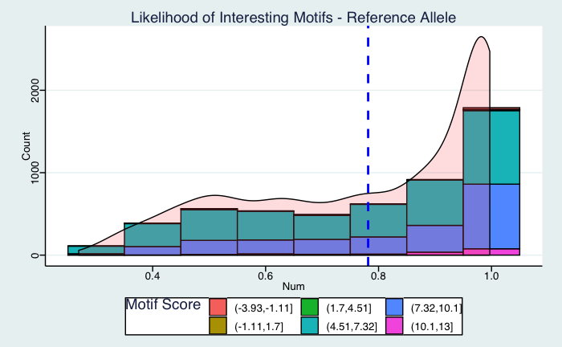

```r
ggplot(all_snp_pwms_ref, aes(x=as.numeric(Num), fill=cut(as.numeric(MotifScore), 6))) +
     geom_histogram(binwidth=.1, color="black") +
     theme_stata() +
     geom_density(alpha=.2, fill="#FF6666", aes(y=..count../8)) +
     geom_vline(aes(xintercept=mean(as.numeric(Num))),
                color="blue", linetype="dashed", size=1) +
     ggtitle("Likelihood of Interesting Motifs - Reference Allele") +
     scale_fill_discrete(name="Motif Score") +
     xlab("Num") +
     ylab("Count")
```

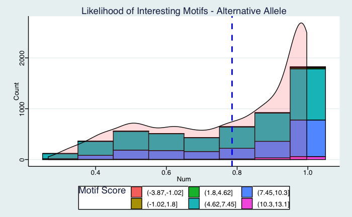

```r
ggplot(all_snp_pwms_alt, aes(x=as.numeric(Num), fill=cut(as.numeric(MotifScore), 6))) +
     geom_histogram(data=all_snp_pwms_alt, binwidth=.1, color="black") +
     scale_fill_discrete(name="Motif Score") +
     theme_stata() +
     geom_density(alpha=.2, fill="#FF6666", aes(y=..count../8)) +
     geom_vline(aes(xintercept=mean(as.numeric(Num))),
                color="blue", linetype="dashed", size=1) +
     ggtitle("Likelihood of Interesting Motifs - Alternative Allele") +
     scale_fill_discrete(name="Motif Score") +
     xlab("Num") +
     ylab("Count")
```

Plot the sequence score of the motif with the ref allele versus the sequence score of the motif with the alt allele. I think we should do this! What would be even easier to plot is 1) among motifs found when the SNP was flipped to alt, the PWM probability of the ref allele versus the PWM probability of the alt allele And 2) vice versa for motifs found when snp was flipped to ref What you have is already halfway there! Just a thought - maybe better to not spend time chasing this and better to focus on LD pruning

Sort by highest to lowest pwm?

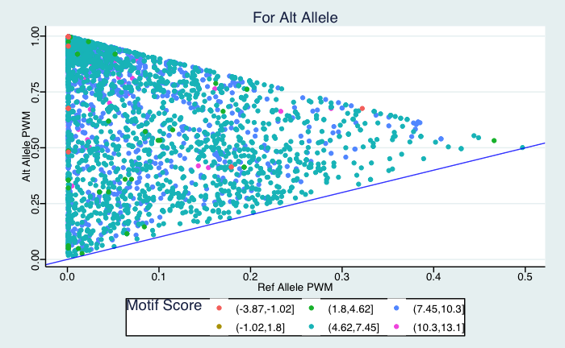

```r
ggplot(all_snp_pwms_alt, aes(x=OtherPWM, y=AssessedPWM, color=cut(as.numeric(MotifScore), 6))) +
  geom_point() +
  theme_stata() +
  scale_colour_discrete(name="Motif Score") +
  ggtitle("For Alt Allele") +
  labs(x="Ref Allele PWM", y="Alt Allele PWM") + geom_abline(color="blue", alpha=.8)
```

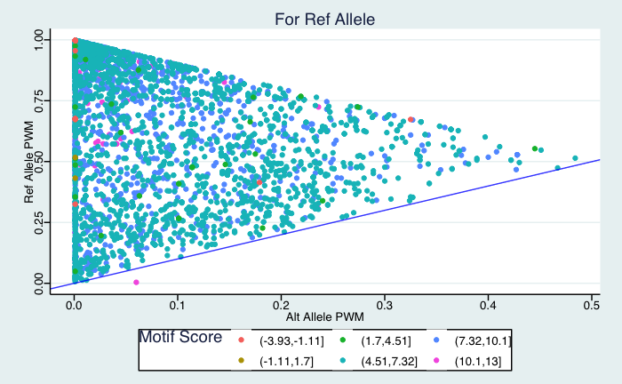

```r
ggplot(all_snp_pwms_ref, aes(x=AssessedPWM, y=OtherPWM, color=cut(as.numeric(MotifScore), 6))) +
  geom_point() +
  theme_stata() +
  scale_colour_discrete(name="Motif Score") +
  ggtitle("For Ref Allele") +
  labs(x="Alt Allele PWM", y="Ref Allele PWM") + geom_abline(color="blue", alpha=.8)
```

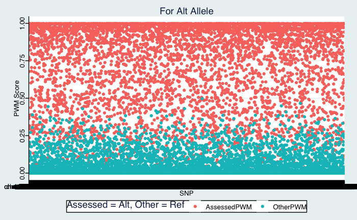

```r
df2 <- melt(data.frame(all_snp_pwms_alt[order(all_snp_pwms_alt$AssessedPWM - all_snp_pwms_alt$OtherPWM), c("SNP", "AssessedPWM", "OtherPWM")], id.vars='SNP'))
q <- ggplot(df2, aes(x=SNP, y=value, color=factor(variable))) +
  geom_point() +
  theme_stata() +
  scale_colour_discrete(name="Assessed = Alt, Other = Ref") +
  ggtitle("For Alt Allele") +
  labs(x="SNP", y="PWM Score")
q
```

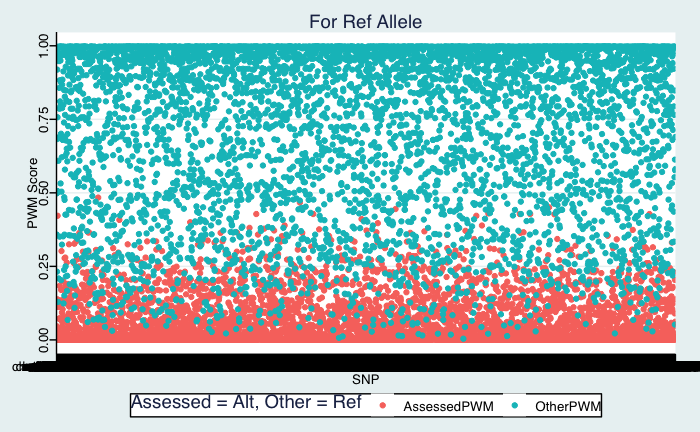

```r
df2 <- melt(data.frame(all_snp_pwms_ref[order(all_snp_pwms_ref$AssessedPWM - all_snp_pwms_ref$OtherPWM), c("SNP", "AssessedPWM", "OtherPWM")], id.vars='SNP'))
g <- ggplot(df2, aes(x=SNP, y=value, color=factor(variable))) +
  geom_point() +
  theme_stata() +
  scale_colour_discrete(name="Assessed = Alt, Other = Ref") +
  ggtitle("For Ref Allele") +
  labs(x="SNP", y="PWM Score")
g
```

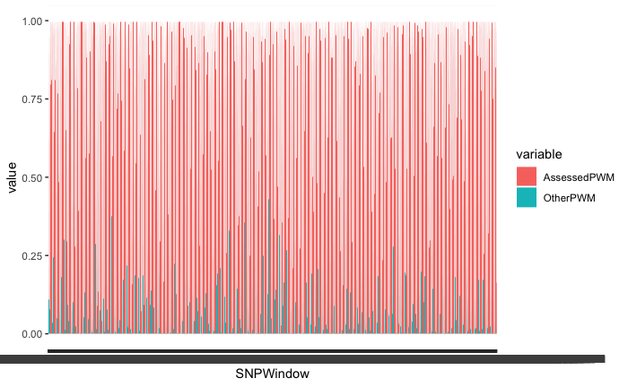

```r
df2 <- melt(data.frame(all_snp_pwms_alt[order(all_snp_pwms_alt$AssessedPWM - all_snp_pwms_alt$`OtherPWM`), c("SNPWindow", "AssessedPWM", "OtherPWM")], id.vars='SNPWindow'))
g <- ggplot(df2, aes(x=SNPWindow, y=value, fill=variable)) +
    geom_bar(stat='identity', position='dodge')
df2 <- melt(data.frame(all_snp_pwms_ref[order(all_snp_pwms_ref$'OtherPWM'), c("SNPWindow", "AssessedPWM", "OtherPWM")], id.vars='SNPWindow'))
q <- ggplot(df2, aes(x=SNPWindow, y=value, fill=variable)) +
    geom_bar(stat='identity', position='dodge')
g
```

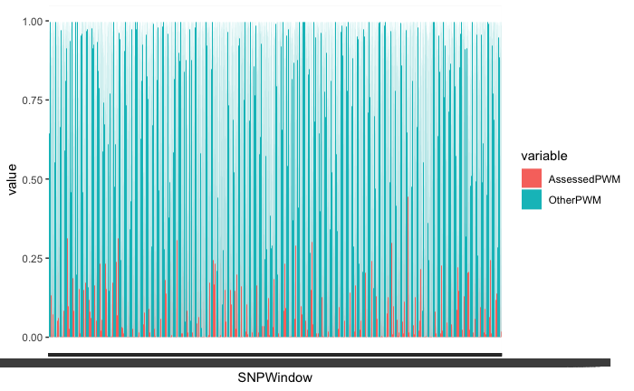

```r
q
```

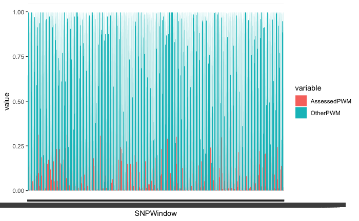

```r
df2 <- melt(data.frame(all_snp_pwms_ref[order(all_snp_pwms_ref$AssessedPWM - all_snp_pwms_ref$`OtherPWM`), c("SNPWindow", "AssessedPWM", "OtherPWM")], id.vars='SNPWindow'))
ggplot(df2, aes(x=SNPWindow, y=value, fill=variable)) +
    geom_bar(stat='identity', position='dodge')
```